# OOPS_TMT_Data_Processing_And_QC

2023-03-29 This notebook will take my TMT data from my experiment and process the data, filter for Crap proteins and QC

```r
library(camprotR)
library(MSnbase)
library(ggplot2)
library(tidyr)
library(dplyr)

library(here)
```

```r
psm_data <- read.delim(here('Extdata/4034462575_AF_input-(1)_PSMs.txt'))
```

```r
crap_fasta_inf <-here('Extdata/crap.fasta')

# Load the cRAP FASTA used for the PD search

crap_fasta <- Biostrings::fasta.index(crap_fasta_inf, seqtype = "AA")

# Extract the non-cRAP UniProt accessions associated with each cRAP protein
crap_accessions <- crap_fasta %>%
  pull(desc) %>%
  stringr::str_extract_all(pattern="(?<=\\|).*?(?=\\|)") %>%
  unlist()
```

No cRAP proteins are removed! Have they already been removed before the file was exported from PD? That’s not normally the case. Check with Bini?

```r
psm_data_flt <- parse_features(
  psm_data,
  crap_proteins=crap_accessions,
  TMT=TRUE,
  level = 'PSM')
```

```
Parsing features...
63014 features found from 7245 master proteins => Input
115 cRAP proteins supplied
0 proteins identified as 'cRAP associated'
63014 features found from 7245 master proteins => cRAP features removed
63013 features found from 7244 master proteins => features without a master protein removed
60341 features found from 6746 master proteins => features with non-unique master proteins removed
```

Futher sanity check for whether there are any peptides from contaminant proteins present

```r
# Will be True if PD thinks the peptides is from a contaminant protein
table(psm_data$Contaminant)

# Depending on the fasta entry names and how they are parsed, the
# cRAP proteins can sometimes be called 'sp' erroneously
# Run pull(crap_fasta, desc) to see why
psm_data %>% filter(grepl('sp', Protein.Accessions))
```

[output not shown]

Re-run `parse_features` without filtering cRAP (same results as previous)

```r
psm_data_flt <- parse_features(
  psm_data,
  filter_crap=FALSE,
  TMT = TRUE,
  level = 'PSM'
)
```

```
Parsing features...
63014 features found from 7245 master proteins => Input
63013 features found from 7244 master proteins => features without a master protein removed
60341 features found from 6746 master proteins => features with non-unique master proteins removed
```

```r
table(rowSums(is.na(exprs(psm))))
```

```
    0     1     2     3     4     5     6     7     8     9    10    11    12    13    14    15
53935   293   122    73    61    27    22    28    19    22    19    18     9    13    13  5667
```

We have some rows in our PSM quantification where all samples are NA. We want to remove these

```r
table(rowSums(is.na(exprs(psm))))
```

```
    0     1     2     3     4     5     6     7     8     9    10    11    12    13    14    15
53935   293   122    73    61    27    22    28    19    22    19    18     9    13    13  5667
```

```r
psm <- psm[rowSums(is.na(exprs(psm))) < ncol(exprs(psm))]
table(rowSums(is.na(exprs(psm))))
```

```
    0     1     2     3     4     5     6     7     8     9    10    11    12    13    14
53935   293   122    73    61    27    22    28    19    22    19    18     9    13    13
```

Plot intensity distributions

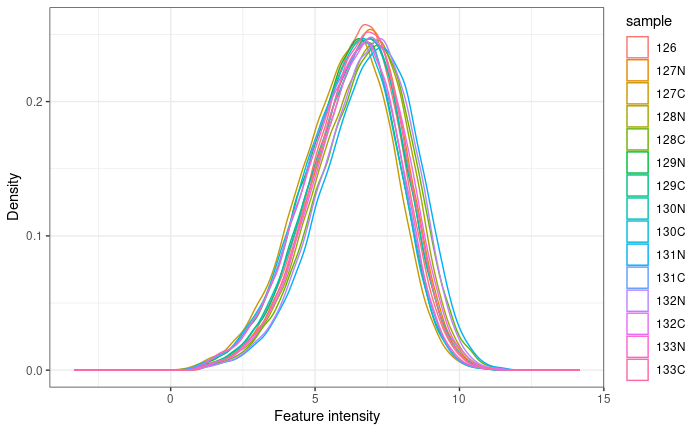

```r
plot_quant(log(psm, base=2), method='density')
```

We want to remove low Signal:Noise (S:N) PSMs, since the quantification values will be less accurate and there will be more missing values. We can inspect the relationship between S:N and missing values using the plot_missing_SN function.

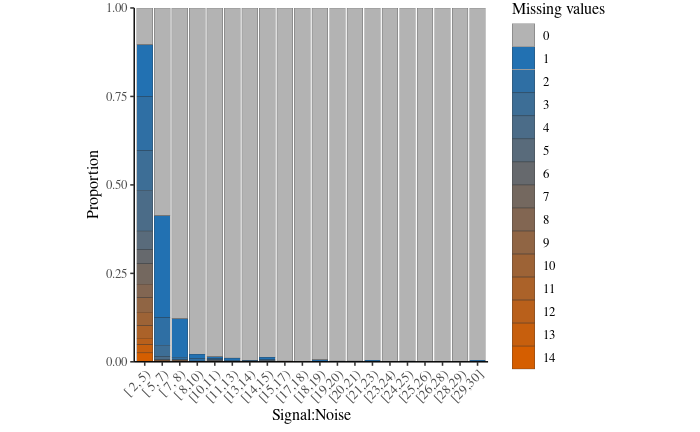

We can also look into this relationship at the tag level using plot_missing_SN_per_sample. In this case, there is no tag which appears to have a high proportion of missing values when signal:noise > 5. If there were, this may warrant further exploration, e.g was one of the sample preparations inadequate such that fewer peptides were labeled?

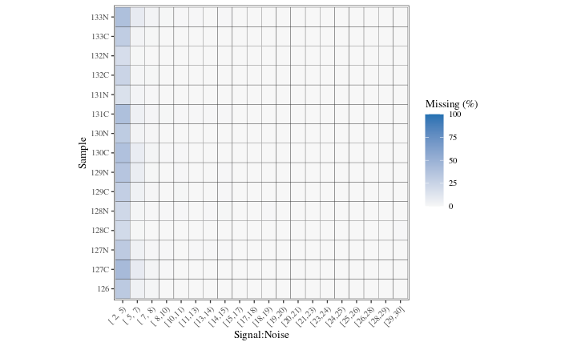

Based on the above, we will filter the PSMs to only retain those with S:N > 5 using filter_TMT_PSMs. Using the same function, we will also remove PSMs with interference/co-isolation >50%.

```r
psm_filt_sn_int <- filter_TMT_PSMs(psm, inter_thresh = 50, sn_thresh = 5)
```

For PSM to protein summarisation, we will use naive ‘sum’ summarisation (MSnbase::combineFeatures(method = ‘sum’)). This approach does not appropriately handle missing values, since it either returns NA if any value is missing, or, with na.rm=TRUE included, replaces NA with zero where there is at least one finite quantification value for a protein. As such, we will remove the very few PSMs with any missing values

```r
psm_filt_sn_int_missing <- psm_filt_sn_int %>%
  MSnbase::filterNA()
```

Typically, one removes proteins with a single PSM, the so-called ‘one-hit wonders’, on the basis that these are more likely to be false positive identifications, and the quantification is only drawn from a single observation.

```r
psm_filt_sn_int_missing_n_features <- psm_filt_sn_int_missing %>%
  camprotR::restrict_features_per_protein(min_features=2, plot=FALSE)
```

Below, we summarise the number of PSMs at each level of filtering

```r
dim(psm_data)
```

```
[1] 63014    77
```

```r
dim(psm)
```

```
[1] 54674    15
```

```r
dim(psm_filt_sn_int)
```

```
[1] 52233    15
```

```r
dim(psm_filt_sn_int_missing)
```

```
[1] 51963    15
```

```r
dim(psm_filt_sn_int_missing_n_features)
```

```
[1] 50697    15
```

Below, we perform the summarisation.

```r
protein <- psm_filt_sn_int_missing %>%
  MSnbase::combineFeatures(
    groupBy = fData(psm_filt_sn_int_missing)$Master.Protein.Accession,
    method = 'sum')
```

Finally, we assess the quantification distribution and normalise the protein-level abundances

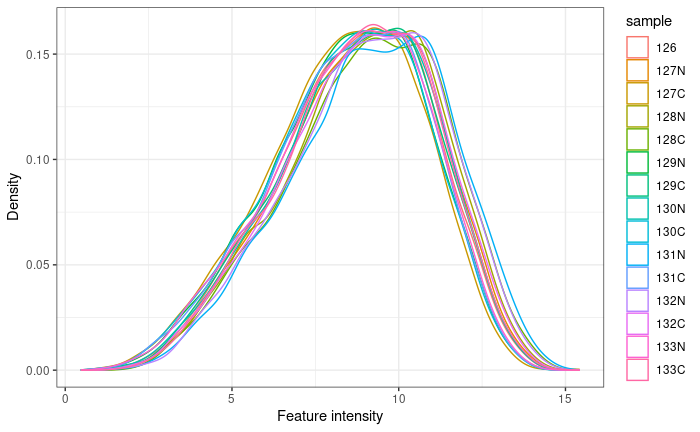

Protein-level intensity distributions are very similar

The next step should be to normalise the protein-level intensities.

Here we will apply median normalisation such that all column (sample) medians match the grand median. In MSnbase::normalise, this is called diff.median. Since the intensities are log-Gaussian distributed, we log2-transform them before performing the normalisation.

Median normalisation is a relatively naive form of normalisation, since we are only applying a transformation using a single correction factor for each sample. This is most likely to be appropriate when the samples being compared are similar to one another, which is the case here.

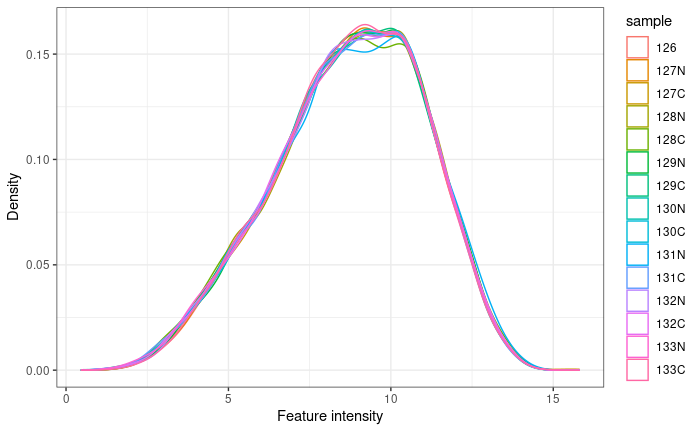

```r
protein_norm <- MSnbase::normalise(log(protein, base=2), method='diff.median')

plot_quant(protein_norm, method='density')
```

Remember that we can check the processing information for our MSnSet if we are in doubt about the processing. Here, it tells us that we log2 transformed and then used diff.median normalisation.

```r
processingData(protein_norm)
```

```
- - - Processing information - - -
Subset [60341,15][54674,15] Wed Apr 26 13:50:21 2023
Subset [54674,15][54674,15] Wed Apr 26 13:51:57 2023
Subset [54674,15][52725,15] Wed Apr 26 13:51:58 2023
Subset [52725,15][52233,15] Wed Apr 26 13:51:58 2023
Subset [52233,15][51963,15] Wed Apr 26 13:52:23 2023
Removed features with more than 0 NAs: Wed Apr 26 13:52:23 2023
Dropped featureData's levels Wed Apr 26 13:52:23 2023
Combined 51963 features into 6557 using sum: Wed Apr 26 14:01:53 2023
Log transformed (base 2) Wed Apr 26 14:04:27 2023
Normalised (diff.median): Wed Apr 26 14:04:27 2023
 MSnbase version: 2.14.2
```

Now we have filtered our PSM-level quantification, summarised to protein-level and normalised. We can use this object to perform downstream visualisation, data exploration and statistical analysis etc.

We save the object to disk so we can read it back into memory when we need it

```r
saveRDS(psm_filt_sn_int_missing, here('Results/input_psm_filt.rds'))
saveRDS(protein_norm, here('Results/input_tmt_protein.rds'))
```

Sanity check that all proteins in the final PSM object are in the protein-level object

```r
length(setdiff(fData(psm_filt_sn_int_missing)$Master.Protein.Accessions,
               fData(protein_norm)$Master.Protein.Accessions))
```

```
[1] 0
```